# Econ 144 Project 3

# ETS Model

```r
# fit ETS model
ets_model <- ets(train)

# summarize ETS model
summary(ets_model)
```

```
## ETS(M,A,M)
##
## Call:
##  ets(y = train)
##
##   Smoothing parameters:
##     alpha = 0.4359
##     beta  = 0.0044
##     gamma = 1e-04
##
##   Initial states:
##     l = 26945.978
##     b = 1364.6938
##     s = 1.0881 0.9386 0.8969 1.0765
##
##   sigma:  0.1106
##
##      AIC     AICc      BIC
## 2266.395 2268.395 2289.842
##
## Training set error measures:
##                     ME     RMSE      MAE      MPE     MAPE      MASE       ACF1
## Training set -945.6958 8153.273 5642.513 -2.01206 7.663198 0.6996604 0.07971911
```

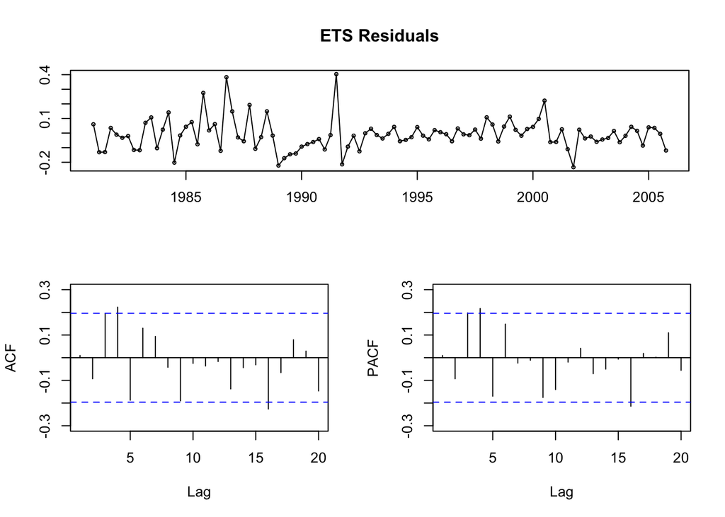

```r
# plot residuals of the ETS model
ets.resid <- resid(ets_model)
tsdisplay(ets.resid, main = "ETS Residuals")
```

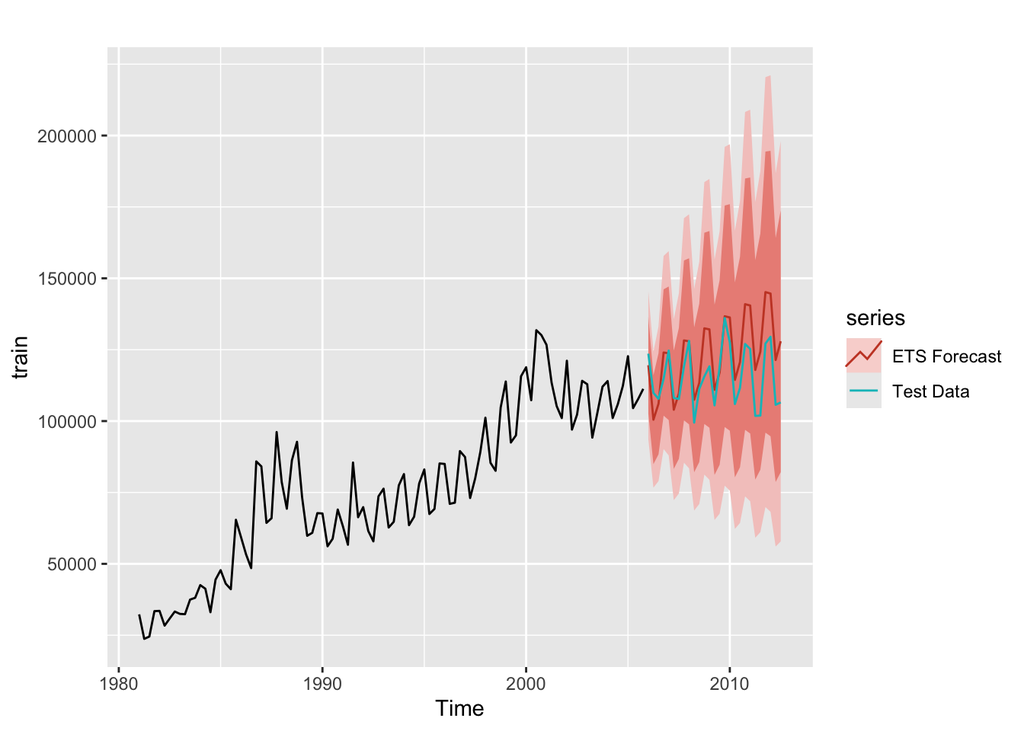

```r
# forecast with the ETS model
forecast_ets <- forecast(ets_model, h = 27)

# plot the forecast
autoplot(train) + autolayer(forecast_ets, series = "ETS Forecast") + autolayer(test,
    series = "Test Data")
```

```r
Box.test(ets.resid, type = "Ljung-Box")
```

```
##
##  Box-Ljung test
##
## data:  ets.resid
## X-squared = 0.0095057, df = 1, p-value = 0.9223
```

```r
accuracy(forecast_ets, test)
```

```
##                      ME      RMSE      MAE       MPE     MAPE      MASE
## Training set  -945.6958  8153.273 5642.513 -2.012060 7.663198 0.6996604
## Test set     -7706.4075 11426.111 9358.811 -6.791486 8.253004 1.1604739
##                    ACF1 Theil's U
## Training set 0.07971911        NA
## Test set     0.62001142 0.8749644
```

The ETS model performs better than the ARIMA model as the RMSE on the test data is 11426 and the MAE is 9359, both lower than the ARIMA model.

# Holt-Winters

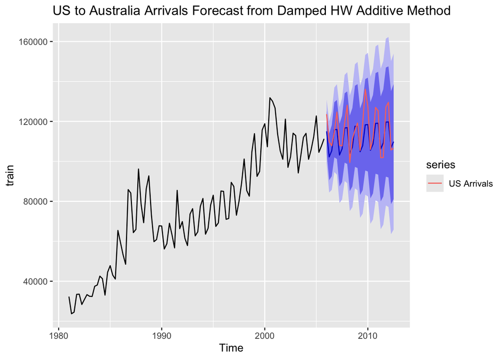

```r
us_arrivals <- aus_arrivals %>%
  dplyr::filter(Origin == "US")

us_arrivals_ts <- ts(us_arrivals$Arrivals, start = c(1981, 1), frequency = 4)

#create train/test split (for forecasts)
train <- window(us_arrivals_ts, end = c(2005, 4))
test <- window(us_arrivals_ts, start = c(2006, 1))
HW_d <- hw(train, seasonal = c("additive"), damped = TRUE, h = 27)
autoplot(HW_d, main = "US to Australia Arrivals Forecast from Damped HW Additive Method") +
  autolayer(test, series = "US Arrivals")
```

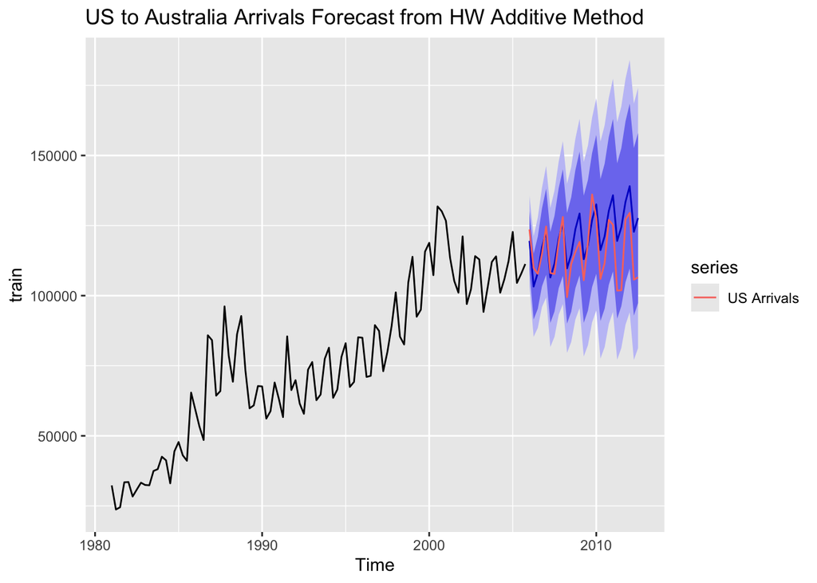

```r
HW <- hw(train, seasonal = c("additive"), damped = FALSE, h = 27)
autoplot(HW, main = "US to Australia Arrivals Forecast from HW Additive Method") +
  autolayer(test, series = "US Arrivals")
```

```r
accuracy(HW_d, test)
```

```
##                      ME     RMSE      MAE        MPE     MAPE      MASE
## Training set   10.54916 7753.504 5495.127 -0.9738518 8.075864 0.6813847
## Test set     3815.50707 6909.221 5568.880  2.9645096 4.655313 0.6905300
##                       ACF1 Theil's U
## Training set -0.0004134766        NA
## Test set      0.1668388157  0.499185
```

```r
accuracy(HW, test)
```

```
##                       ME     RMSE      MAE        MPE     MAPE      MASE
## Training set   -27.29228 7854.116 5542.519 -0.5988655 7.911434 0.6872613
## Test set     -5696.37832 9721.825 7648.747 -5.2783678 6.868359 0.9484293
##                     ACF1 Theil's U
## Training set 0.007112139        NA
## Test set     0.532585469 0.7363468
```

We chose the damped Holt-Winters model due to its lower RMSE and MAE values.

[figure not shown]

```r
Box.test(resid.HW, type = "Ljung-Box")
```

```
##
##  Box-Ljung test
##
## data:  resid.HW
## X-squared = 1.7614e-05, df = 1, p-value = 0.9967
```

# Prophet Model

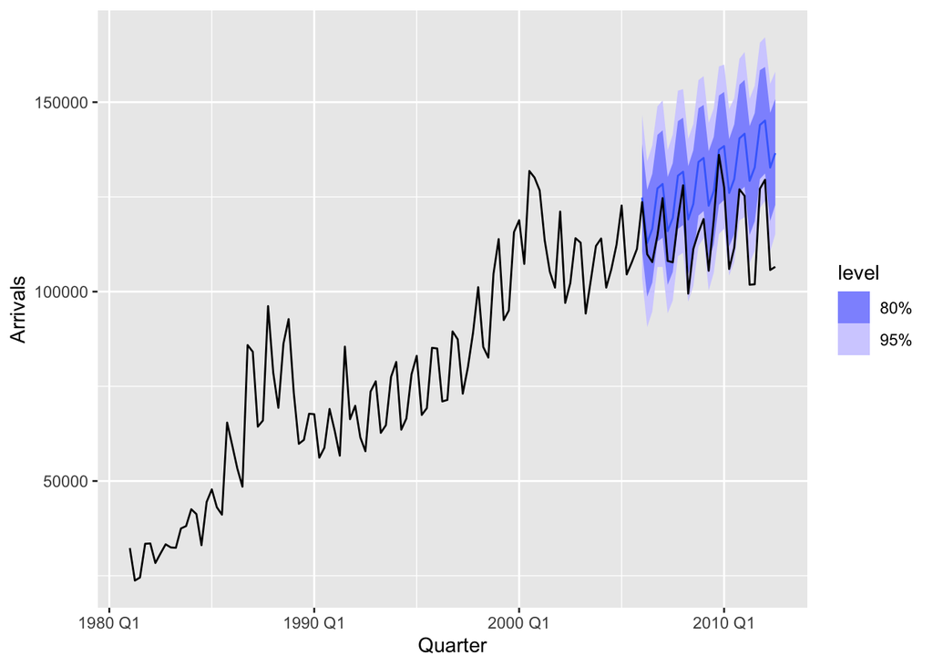

```r
train_prophet <- aus_arrivals %>%
  dplyr::filter(Origin == "US") %>%
  dplyr::filter(as.integer(format(Quarter, "%Y")) <= 2005)

test_prophet <- aus_arrivals %>%
  dplyr::filter(Origin == "US") %>%
  dplyr::filter(as.integer(format(Quarter, "%Y")) >= 2006)

prophet_fit <- train_prophet %>%
  model(
    prophet = prophet(Arrivals ~ season(period = 4, order = 2,
                                    type = "additive"))
  )

# Use an additive model since the seasonality is relatively constant over time


prophet_forecast <- prophet_fit %>% forecast(h = 27)
prophet_forecast %>% autoplot(us_arrivals)
```

We decide to fit an additive prophet model of order 2 since the frequency is quarterly and the seasonality is relatively constant over time. The prophet model does not seem to fit the data very well as it predicts a continuing upward trend, although the actual data flattens out.

```r
prophet_forecast %>% accuracy(test_prophet)
```

```
## # A tibble: 1 × 11
##   .model  Origin .type      ME   RMSE    MAE   MPE  MAPE  MASE RMSSE  ACF1
##   <chr>   <chr>  <chr>   <dbl>  <dbl>  <dbl> <dbl> <dbl> <dbl> <dbl> <dbl>
## 1 prophet US     Test  -14170. 16379. 14170. -12.7  12.7   NaN   NaN 0.501
```

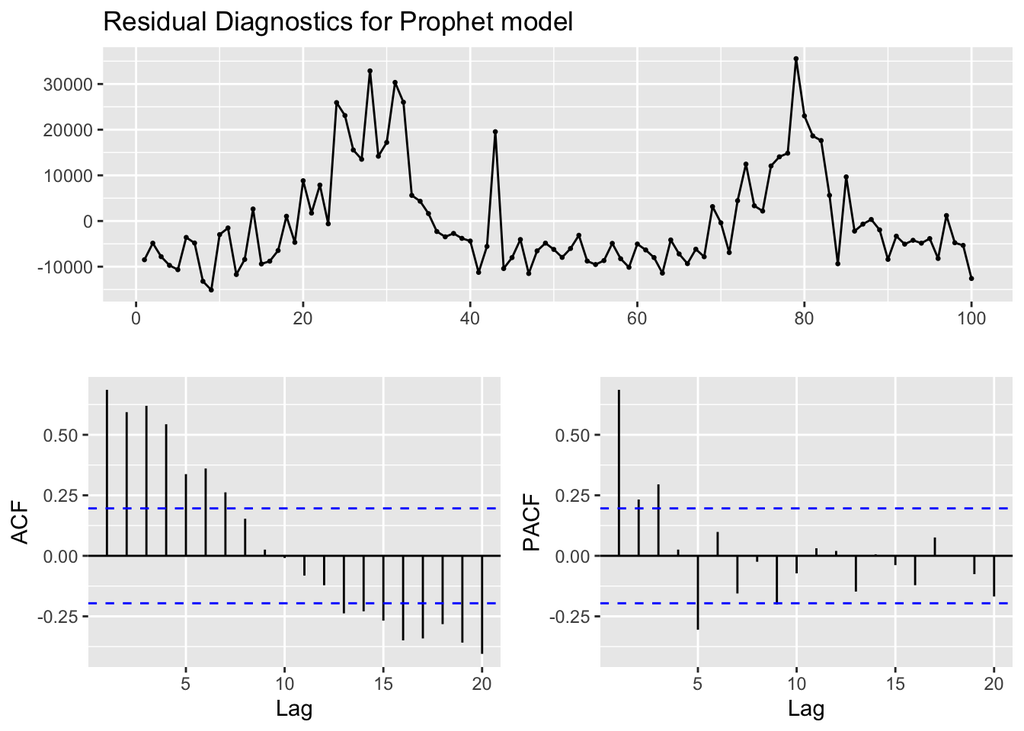

```r
prophet.resid <- residuals(prophet_fit)
ggtsdisplay(prophet.resid$.resid, main = "Residual Diagnostics for Prophet model")
```

```r
Box.test(prophet.resid$.resid, type = "Ljung-Box")
```

```
##
##  Box-Ljung test
##
## data:  prophet.resid$.resid
## X-squared = 48.445, df = 1, p-value = 3.397e-12
```

# NNETAR Model

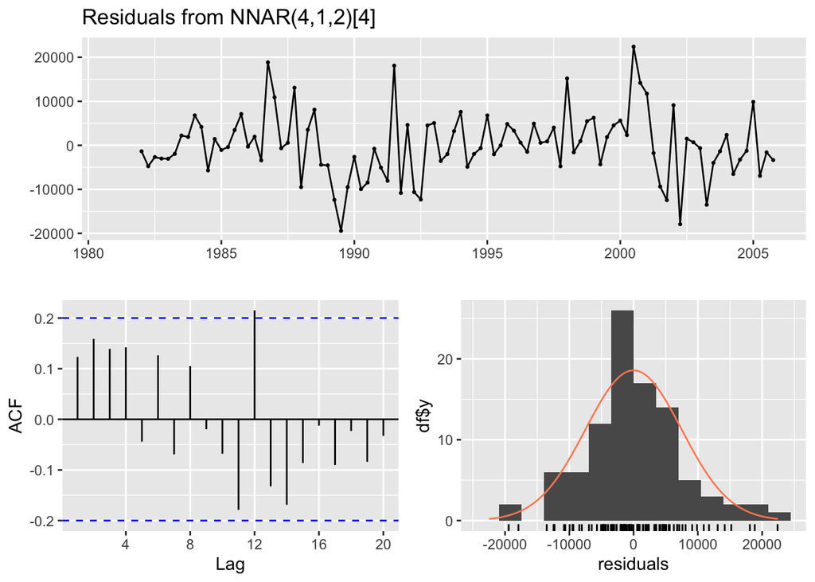

```
##
##  Ljung-Box test
##
## data:  Residuals from NNAR(4,1,2)[4]
## Q* = 11.612, df = 8, p-value = 0.1694
##
## Model df: 0.   Total lags used: 8
```

```r
# convert data to time series
us_arrivals_ts <- ts(us_arrivals$Arrivals, start = c(1981, 1), frequency = 4)

# create train/test split (for forecasts)
train <- window(us_arrivals_ts, end = c(2005, 4))
test <- window(us_arrivals_ts, start = c(2006, 1))

# Fit NNETAR Model
arrival_nnetar <- nnetar(train)

# Evaluate the residuals
checkresiduals(arrival_nnetar)
```

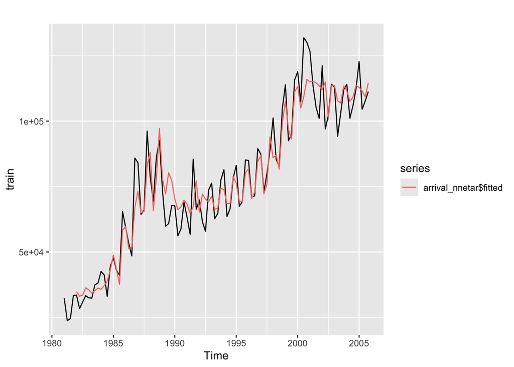

```r
# Plot the model fit
autoplot(train) + autolayer(arrival_nnetar$fitted)
```

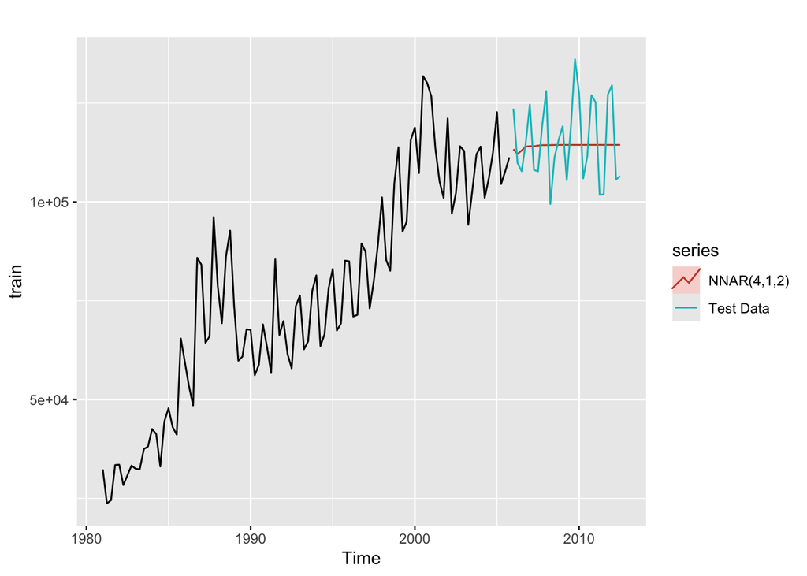

```r
forecast.nnetar <- forecast(arrival_nnetar, h = 27)
autoplot(train) + autolayer(forecast.nnetar, series = "NNAR(4,1,2)") + autolayer(test,
    series = "Test Data")
```

```r
accuracy(forecast.nnetar, test)
```

```
##                       ME      RMSE      MAE       MPE     MAPE     MASE
## Training set   -7.888098  7446.268 5575.936 -1.025137 7.456288 0.691405
## Test set     1344.643565 10063.264 8765.069  0.428268 7.522830 1.086851
##                    ACF1 Theil's U
## Training set 0.12321196        NA
## Test set     0.03891025 0.7232255
```

# Forecast Combination

For our combination model, we will average the forecasts from ETS, ARIMA, HW, and NNAR models.

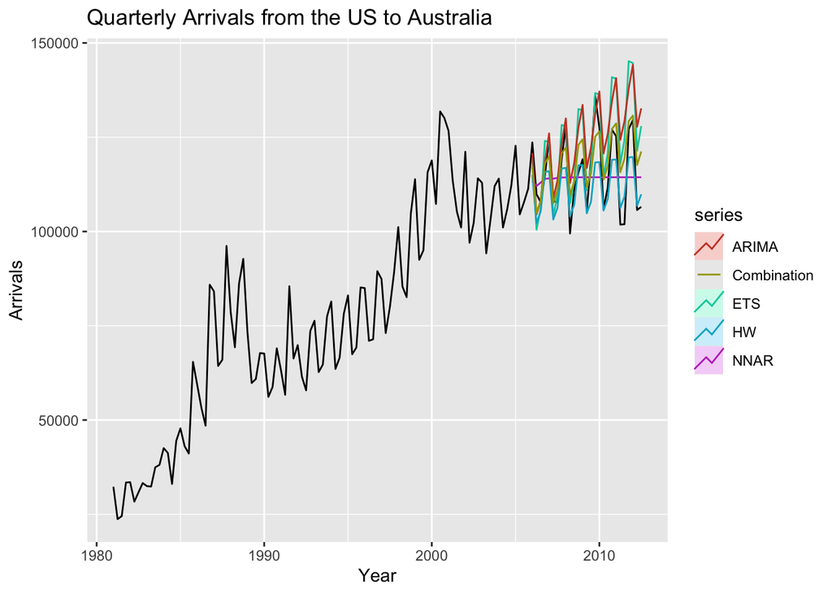

```r
#convert data to time series
us_arrivals_ts <- ts(us_arrivals$Arrivals, start = c(1981, 1), frequency = 4)

#create train/test split (for forecasts)
train <- window(us_arrivals_ts, end = c(2005,4))
test <- window(us_arrivals_ts, start = c(2006,1))

h <- length(us_arrivals_ts) - length(train)

ETS <- forecast(ets(train), h=h)
ARIMA <- forecast(auto.arima(train),
  h=h)
HW <- hw(train, seasonal = c("additive"), damped = TRUE, h = 27)
NNAR <- forecast(nnetar(train), h=h)
Combination <- (ETS[["mean"]] + ARIMA[["mean"]] + NNAR[["mean"]] + HW[["mean"]])/4

autoplot(us_arrivals_ts) +
  autolayer(ETS, series="ETS", PI=FALSE) +
  autolayer(ARIMA, series="ARIMA", PI=FALSE) +
  autolayer(NNAR, series="NNAR", PI=FALSE) +
  autolayer(HW, series = "HW", PI = FALSE) +
  autolayer(Combination, series="Combination") +
  xlab("Year") + ylab("Arrivals") +
  ggtitle("Quarterly Arrivals from the US to Australia")
```

Visually, the combination model seems to fit the data pretty well, but it looks like the Holt-Winters model still has the best fit.

```r
Combination %>% accuracy(test)
```

```
##                 ME     RMSE      MAE       MPE     MAPE      ACF1 Theil's U
## Test set -2941.051 7383.842 5767.298 -2.933661 5.194788 0.3450797 0.5534617
```

# Conclusion and Future Work

Through this project, we attempted to forecast quarterly arrivals from the United States to Australia using data between 1981 Q1 and 2012 Q3. We fit seasonal ARIMA, ETS, Holt-Winters, Prophet, and NNAR models to the data, then performed a forecast combination between the ARIMA, ETS, HW, and NNAR models.

In the future, we could compare try to improve our combined model by changing the weights on each of the individual models. For example, it may have been better to exclude the ARIMA model and place more weight on the Holt-Winters model.

# References

Data from fpp3: Data for “Forecasting: Principles and Practice” (3rd Edition) by Rob Hyndman